# Midterm exam

# Midterm

Space for TA/grader comments here!

(Note to TAs: copy this in the middle of the code for more elaborate comments)

**Change log**:

- 2/Mar/24: 1 pm. Updated points to 60 total (previously 55) adding questions 1e2, 1f, 4.d
- 2/Mar/24: 7 pm. Fixed rendering to generate a standalone html file, clarified format

## Prologue

This exam is meant to test these topics you have learnt in the last two months while serving as practice to brush up these concepts. We anticipate this to be at the same complexity/time commitment as a homework assignment, so treat this as a **learning opportunity** where you have all the resources at your disposal **including office hour help** to help you grasp this content. **25% of the points** will be given **in each question** involving `R` for providing short explanations (and **documentation** in code) that **demonstrate that you understand** what the R code you wrote does.

Please remember that **there are many ways of answering the R questions**, and all approaches are valid for grading. *If you tried and couldn’t answer any question, partial points will be given if you add enough explanation to indicate that you are on the right path.* If you are having trouble understanding or interpreting any question or believe you spent too long lost in a wrong direction, please do reach out to the TAs/discuss with peers/post on the discussion board/come to office hours. If you **need extra time** to do this exam **for any reason** please don’t hesitate to email Prashant with the subject `BIOS 538:`

Emphasis will be on the later half that uses the more efficient vectorized functions from the `tidverse` ecosystem, contrasting this to more verbose approaches such as `for ()` loops and `if ().. else` statements from the first few lectures. These are the learning goals from this exam:

- Making and using functions + documentation using [roxygen2](https://roxygen2.r-lib.org/articles/rd.html#basics) style comments is very useful.
- Vectorization is better than for loops : a) in a normal function b) within a dplyr chain
- Making informative plots with proper axis labels, titles, orientation and annotations is handy to communicate more effectively.

## Format : submit **both `.qmd` script + `.html` output**

- Make sure to **change the filename** to include your **first name** as a suffix, such as **`midterm_prashant.qmd`**
- Please type out your **code within R chunks** in this `.qmd` (quarto markdown) file
  - along with **documentation above or next to the line of code** to **concisely** explain the purpose of the line**.**
- Add overall comments/text to explain your solution *where relevant,* such as steps taken to attempt the answer etc. especially when you didn’t get the intended result.

  *You can copy the first 2 words from any comment and paste it to make a box of this reddish text so TAs can see your answers quickly between the question text.*
- **Please make sure to run and test the `R` chunks in RStudio before submission.** Ensure that the file renders into a `.html` of >= 1MB file.
- `Render` the document into the `.html` format and submit this along with the `.qmd` file on Canvas
  - If you are unable to render due to errors in the code, you can add the option `#| eval: false` as the first line below the `{r ..}` in the chunk giving the error (*see Q4 chunks for example*) to prevent it from being run while rendering (*this way the TAs can still see your partially working code for evaluation)*. Or you can change your R code into comments (but this will be harder to read)
- Cite your sources by pasting links below the answers to each question. Acknowledge collaborators in the credits at the beginning and attribute any general sources of inspiration at the end.

## Resources

1. Use this [section](https://r4ds.hadley.nz/quarto.html#visual-editor) for a refresher if you are having trouble navigating the quarto file, or doing actions making a code chunk etc.
2. [Interactive tutorial](https://allisonhorst.shinyapps.io/dplyr-learnr/) to brush up `dplyr` functions such as `mutate()`, `filter()`, `arrange()` and others. I strongly recommend going through this exercise step-by-step for gaining confidence. Link - https://allisonhorst.shinyapps.io/dplyr-learnr/
3. Markdown formatting [cheatsheet](https://www.markdownguide.org/cheat-sheet/)

## Points distribution

|  | 0 | Q1 | Q2 | Q3 | Q4 | Q5 | Q6 | Q7 | Q8 | sum |
| --- | --- | --- | --- | --- | --- | --- | --- | --- | --- | --- |
| Reg | - | 10 | 7 | 9 | 8 | 12 | 6 | 3 | 5 | 60 |
| Bonus | 1+2 + 1 | 2 |  |  |  | 2 | 2 | 3 | 1 | 14 |

```r
library(tidyverse) # for dplyr, pipe and ggplot stuff
```

# Questions

## 0.bonus. Best practices (2 points)

Follow these best practices when writing your code and text for the document for a bonus

- Label your `{r}` chunks with something short and informative using `-` as the separator between words
- Ensure your code is [tidyverse style guide](https://style.tidyverse.org/syntax.html) compliant to make it more readable by incorporating the tips; or use the [styler](https://r4ds.hadley.nz/workflow-style) to automatically do this before submission. For example:
  - spaces after the `# ..` for comments
  - spaces before the `+` for `ggplot(..) +`
  - indent your code to make the most sense for things on the same line, for example

```r
# # library(tidyverse)
# ggplot(df, aes(a1, a2)) + # keeping it short when few options
#   geom_point()
#
# ggplot(df,
#        aes(a1, a2, # expanding into newer lines when there's more options
#            colour = a3, shape = a4, # similar things grouped together
#            frame = a5)) +
#   geom_point() +
#   geom_line()
```

## 1. Check your understanding (10 points)

(~ 1 point for each question x 10 + 2 bonus)

### *1a. Quarto vs `.R`*

*Explain in your own words what an R Markdown/Quarto file is compared to a normal R script. Give one benefit of using these types of files.*

An R Markdown or Quarto file is an extension of R that allows for the integration of plain text and code chunks. These files can be can be formatted as HTML, PDF, or MS files. R Markdown and Quarto also allow for the integration of figures such as images in the document. The main difference between Rmd and Quarto is that Rmd is tied to the R language, while Quarto files support the usage of various languages such as Python, Javascript, or Julia.

References: https://quarto.org/docs/faq/rmarkdown.html

https://rmarkdown.rstudio.com/articles_intro.html

### *1b. Documentation*

Why do we have to add documentation to our code? Who is the typical target audience of this code + documentation effort?

The purpose of the documentation in our code is to explain what the code does. Furthermore, the documentation can provide insight into the thought process and reasoning for the written code. In this sense, the target audience of our code can either be our future selves—so that we can edit or pick back up where we left off—or others who will read through our code with the intention of learning or replicating our work.

### *1b.2. Documentation in R*

Grab 3-5 lines of R code from any HW or write some R code to demonstrate how you would document the code with comments very thoroughly for every line and code action.

Make an R chunk for demonstrating this below

```r
city_temp <- c(20, 20, 22, 17, 18)

# The comments in this r-chunk explain what each line; this for loop assigns a logical value for each numerical value given a condition.
for (i in city_temp){ # For a pre-defined numeric vector "city_temp" initialize a for loop that iterates across the vector elements
  if (i > mean(city_temp)) { # If the element in question is greater than the mean value of the vector
    print('TRUE')            # the function will print "TRUE".
  } else print('FALSE')      # Otherwise, the function will print "FALSE"
}
```

```
[1] "TRUE"
[1] "TRUE"
[1] "TRUE"
[1] "FALSE"
[1] "FALSE"
```

In the above demonstration, the documentation is used to explain what the code’s purpose is and how the arguments within in the function operate.

### 1b.3. Documenting R functions

Now do the same with another R chunk below for demonstrating how to add documentation to an R function (from HW/write any function *that does more than calling a single in-built function*). Your documentation should use [roxygen2](https://roxygen2.r-lib.org/articles/rd.html#basics) style comments.

```r
#' get_mean Function
#'
#' @description
#' `get_mean` returns the artimetic mean of its vector argument
#'
#' @details
#' This function takes the sum of all elements within the argument vector and find the length of the vector. It then
#' divides the sum of the elements by the length of the vector.
#'
#' @param `x` is a numeric vector
#'
#' @return A function that takes a numeric vector as an argument and returns the arithmetic mean of the vector
#'
#' @example
#' get_mean(1:5)
#'
#' v <- c(1, 5, 7, 4)
#' get_mean(v)
get_mean <- function(x){
  s <- sum(x)
  l <- length(x)
  avg <- s / l
  return(avg)
}
```

Reference: Class5_demo_loops-functions.R

### 1c. Troubleshooting

Name and cite two ways to interrogate your R code or function to understand what it is doing and also to troubleshoot errors.

One way to interrogate a function is to use the **Question Mark operator** (?). By typing ?*function_name* you can access the R documentation which defines the purpose of the function, the arguments, and also provides interactive examples.

A way to troubleshoot errors in code chunks is to keep an eye out for the red X that shows up on the left hand side of the R code chunk; if you hover this red X with your cursor, it will provide information about missing punctuation or unrecognized arguments.

References:

https://blog.enterprisedna.co/rstudio-help-ways-to-troubleshoot-r-problems/

https://bookdown.org/yih_huynh/Guide-to-R-Book/trouble.html

### 1c.2. Troubleshooting practicals

*We would like to know what is your workflow when R gives an error.*

Give 1 or 2 error messages you encountered along the process of solving this exam and explain how you interpreted and troubleshooted them

Error in tibble(a1 = -5:10, a2 = exp(a1)) :

could not find function “tibble”

I encountered this error message in question 4 part 4 when troubleshooting the tibble code. In this case, the error arose from R being unable to find the tibble() function. This made it clear that the library containing tibble (tidyverse) was not loaded; thus I wrote library(tidyverse) into the code and commented it out so that if the code chunk was run multiple times, R would not attempt to load tidyverse packages each time.

### 1d. Working directory

Describe what a working directory is, why R needs us to define it, and write the function to find the current working directory in R.

The **working directory** is a file pathway on your local drive that establishes a default location for R to source and deposit files. R needs a working directory so that it knows where to search for the desired files from.

Reference: https://bookdown.org/ndphillips/YaRrr/the-working-directory.html

```r
getwd() # This function shows the pathway on your local drive to your current directory
```

```
[1] "C:/Users/justi/OneDrive/Desktop/RICE/BIOS_338/BIOS_338_Git"
```

### 1d.2. Utility of the working dir

Demonstrate the loading of a `csv` file by writing a path relative to (starting from) R’s current working directory in an R chunk below. Discuss the convenience of this compared to an [absolute path](https://networkencyclopedia.com/absolute-path/)

```r
# library(tidyverse) to load tidyverse as I intend to read the csv using read_csv() for a tibble

read_csv("../../Data/histdata.csv") # Since I found the working directory in 1d., I located a csv file in folder a few steps prior to the # ...current directory. To read this file I used the ../ notation to denote one directory up; I used this twice, to move two folders back
# ...and access the Data folder which contained the csv file.
```

There are several benefits to a relative path over an absolute path. For one, when manually rearranging the local files in file explorer, because the relative path does not rely on the entire file path from the system to the desired destination, the rearrangements are less likely to cause the code to break. To address this issue with an absolute path, you would have to edit/verify each directory in the file path, whereas in a relative path, you can simply base the path from the working directory which often makes the path more readable as well.

Reference: https://networkencyclopedia.com/relative-path/

### 1d.3. bonus. working directory vs quarto (+1 point)

How does the working directory differ between `.qmd` scripts and normal `.R` scripts/`Console`. Demonstrate this by calling the function to know the working dir and add screenshots

(*you can add images to this document easily - go to a new line and using the `/`, start typing `image` and select from the list; enter the path where your screenshot image is stored such as* `img/workin_dir_qmd.png` ~ *not that this path is also relative to the qmd*.. (*it’s meta, I know* 😏*)*

### 1e. R packages

What is a package in R? How do you install and load packages? How do you find the documentation for a package?

A package is a collection of objects, functions, data, and code. Packages are compiled with specific purposes and thus offer specific functions. To install a package you would use the install.packages( ) function; the argument for the function should be the name of the desired package in quotes. To load the package, you would use the library( ) function with the argument being the name of the package, but this time, the quotes are not necessary. To find the documentation for a package you could use the **Question Mark operator** again, but with a slight modification. You would type “?*package::object_in_package*”. See example below.

```r
# To find the documentation for the as_tibble() function in the tibble package

?tibble::as_tibble # This specifies the package as tibble and the double colons indicates that the as_tibble() is an object within tibble
```

```
starting httpd help server ... done
```

### 1e.2.bonus: Install R package form github

BONUS: How can you install a package that is not on CRAN? (for example, on github) ; *there’s a direct function or a more manual approach, show either of these approaches for the* `ggbeeswarm` *package*

```r
# install and load devtools package to access the install_github() function
# install.packages("devtools")
# library(devtools)

install_github("eclarke/ggbeeswarm") # The eclarke is the username of the author on github and ggbeeswarm is the name of the repository
library(ggbeeswarm)
```

Reference: https://support.datacamp.com/hc/en-us/articles/360006286174-Installing-R-Packages-Not-Hosted-on-CRAN

### 1f. assigning to a variable vs not

Explain why does assignment hide the result of the calculation in R, find a citation for this statement. Demonstrate two contexts where you observe this behavior

The hiding of calculation results in R is a practice of object-orientated programming. The benefit object-oriented programming, specifically assignments in our case, is that it allows successive writing and maintenance of the code to be much easier and cleaner. For instance, if we are working with a variable with an assignment of a arithmetic operation, it is easier to work with that variable than it is to with the calculated value, especially if the arguments for the arithmetic operation themselves were variables.

```r
# Example

x <- 2 # Assign values to x and y
y <- 3
z <- x + y # Assign the operation of x + y to Z; this way, if the values of x and y change, we can just as easily work
# ...        work with z as before the variables were changed.

z # 5
```

```
[1] 5
```

```r
# Reference: https://cran.r-project.org/doc/manuals/r-release/R-lang.html#Object_002doriented-programming
```

## 2. Creating datasets. (7 point)

### 2a. Make a tibble (1 point)

Let’s create a dataset. First, create a tibble from the vectors below. The named column order of the tibble should be :

- the first names
- the last names

```r
first_names <- c("Albert", "Jane", "Linus", "Carl", "George", "Jennifer")
last_names <- c("Einstein", "Goodal", "Pauling", "Marx", "Church", "Doudna")

# library(tidyverse)
# Create a dataset by assigning a name to the tibble
famous_people <- tibble(x = first_names, y = last_names) # define the first column, x, in tibble as the first name vector and the second column, y, as the last names vector
```

### 2b. Adding a column (2 *points*)

Now, using a `mutate()` call, randomly (from a *uniform distribution*) assign an age **as an integer** between 30-85 for each person, as another column to your data called **age**. **Do not touch the `set.seed` function, that is for grading!**

```r
set.seed(2292025) #Do not edit!

famous_people_age <- famous_people %>% mutate(Age = sample(30:85,6)) # Mutating the famous_people dataset to include a new column of age. The sample() will generate 6 random integer between 30 and 85
famous_people_age
```

```
# A tibble: 6 × 3
  x        y          Age
  <chr>    <chr>    <int>
1 Albert   Einstein    85
2 Jane     Goodal      59
3 Linus    Pauling     51
4 Carl     Marx        53
5 George   Church      71
6 Jennifer Doudna      50
```

### 2c. if..else/conditional computations on a column (4 points)

Now, you want to do some conditional computation to tell the favorite scientist of the person in each row based on their age. These are the rules to decide the favorite scientist based on the age ranges of the person, in the format: `age condition` => `fav_scientist`

- Age between 30-39 => Francis Arnold
- Age between 40-49 => Louis Pasteur
- Age > 49 => Isaac Newton

You need to use only **ONE of the two approaches** below as you prefer. *I would recommend you try out the vectorized approach first, and leave your code in to get +1 bonus point and feedback of where you went wrong even if you moved onto approach 2.*

**Note**: If you are getting errors, you can convert the code into a comment : by selecting and pressing `ctrl + shift + c` ; this will ensure that graders can see your attempt for approach 1 without letting the errors hold up the rendering of the document!

#### Approach 1 : Vectorized

The most efficient way is to use a vectorized [`case_when()`](https://dplyr.tidyverse.org/reference/case_when.html) function to generate the new column (*please lookup the documentation of this function!) / use the alternate approach below*

```r
# case_when()
# I mutates the tibble once again to include the new favorite scientist column and used the case_when() function to
# ... set up the conditions of which scientist was the person's favorite based on their age range. However, in the
# ... previous generation of ages, all of my ages for the people came out above the upper age range of 49, and the
# ... entire list ended up having the same favorite scientist.

famous_people_favorite <- famous_people_age %>% mutate(fav_scientist = case_when(Age >= 30 & Age <= 39 ~ "Francis Arnold",
                                                                                 Age >= 40 & Age <= 49 ~ "Louis Pasteur",
                                                                                 Age > 49 ~ "Isaac Newton"))

famous_people_favorite
```

```
# A tibble: 6 × 4
  x        y          Age fav_scientist
  <chr>    <chr>    <int> <chr>
1 Albert   Einstein    85 Isaac Newton
2 Jane     Goodal      59 Isaac Newton
3 Linus    Pauling     51 Isaac Newton
4 Carl     Marx        53 Isaac Newton
5 George   Church      71 Isaac Newton
6 Jennifer Doudna      50 Isaac Newton
```

#### Aproach 2: using `for()` and `if()..else` workflow

If you are not able to use `case_when()` or want to try a more familiar approach, you can use this approach to iterate on each row using a `for ()` loop and apply a few `if()` conditions and an `else` statement to achieve the same goal. This approach closely mimics the discussion in the review session (`for-if-else` [chunk](https://github.com/BIOS-538/class-worksheets/blob/1caa8a63fac3e291064ab051236fb55f7fcc208d/scripts/Review_Session_Solutions.qmd#L124))

```r
# if..else
```

## 3. Working with existing datasets (9 point)

### 3a. Know thy data (1 point)

We will be working with data about sleeping mammals. Write 1-2 sentences describing what the dataset contains and what the columns mean.

https://rdrr.io/cran/ggplot2/man/msleep.html

```r
sleeping_data <- msleep # reassign a more intuitive name
sleeping_data
```

```
# A tibble: 83 × 11
   name   genus vore  order conservation sleep_total sleep_rem sleep_cycle awake
   <chr>  <chr> <chr> <chr> <chr>              <dbl>     <dbl>       <dbl> <dbl>
 1 Cheet… Acin… carni Carn… lc                  12.1      NA        NA      11.9
 2 Owl m… Aotus omni  Prim… <NA>                17         1.8      NA       7
 3 Mount… Aplo… herbi Rode… nt                  14.4       2.4      NA       9.6
 4 Great… Blar… omni  Sori… lc                  14.9       2.3       0.133   9.1
 5 Cow    Bos   herbi Arti… domesticated         4         0.7       0.667  20
 6 Three… Brad… herbi Pilo… <NA>                14.4       2.2       0.767   9.6
 7 North… Call… carni Carn… vu                   8.7       1.4       0.383  15.3
 8 Vespe… Calo… <NA>  Rode… <NA>                 7        NA        NA      17
 9 Dog    Canis carni Carn… domesticated        10.1       2.9       0.333  13.9
10 Roe d… Capr… herbi Arti… lc                   3        NA        NA      21
# ℹ 73 more rows
# ℹ 2 more variables: brainwt <dbl>, bodywt <dbl>
```

```r
# The dataset contains information regarding the sleep patterns of animals and other related data. For instance, the some
# ... of the columns give information about the animals such as common name, genus, order, diet, and conservation status, while the remaining columns give information regarding, total hours of sleep, hours of REM sleep, length of sleep cycle, and brain/body weight.

# Reference: https://rdrr.io/cran/ggplot2/man/msleep.html
```

### 3b.1. Make a scatter plot (2 *points*)

Next, create a scatterplot using the “sleep_total” column and the “bodywt” column. Color the data points by “vore” column (this describes the diet of the species).

Make the legend caption say “Diet”

Make the x axis “Log of body weight”

Make the y axis “Total Sleep”

Make the size of the dots the size of “brainwt”. Add a best fit regression line. (hint. if the graph looks weird, try log transforming the bodywt variable)

##### (note: some data points will be removed. that is ok)

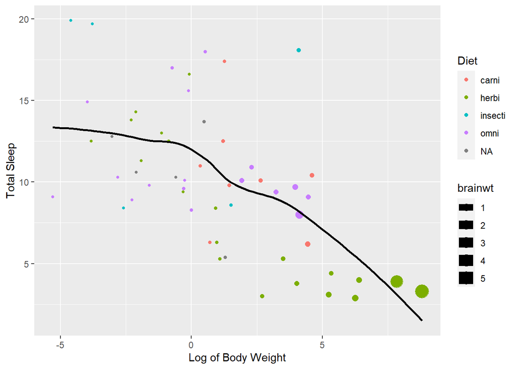

```r
sleep_plot <- ggplot(sleeping_data, aes(x = log(bodywt), y = sleep_total, color = vore, size = brainwt)) + # Create a plot using ggplot(), using the sleeping_data dataset. Set the x variable to be the log of bodywt and the y variable as the total sleep measure. Color code the data based on the diet and size the data points based on brain weight.
  geom_point() + # Add the data points to the ggplot
  geom_smooth(se = FALSE, color = "black") + # Line of best fit; specify color to prevent geom_smooth from generating regression line for each diet
  labs(y = "Total Sleep", x = "Log of Body Weight", color = "Diet") # Adding labels

sleep_plot
```

### 3b.2. Add facet based on “vore” (2 points)

Make the same plot, but facet based on the `vore` column (`facet_..` splits the plot into subsets for each unique value in `vore` and puts them in side-by-side plots)

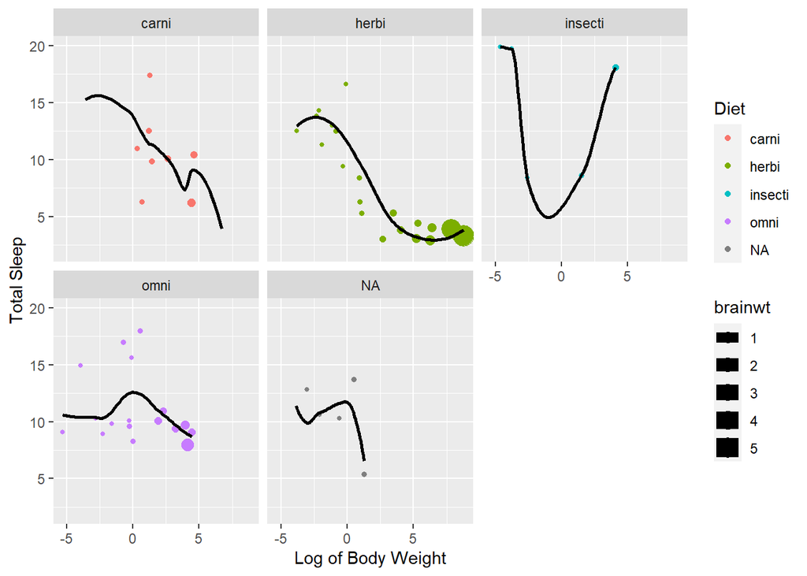

```r
sleep_facet <- ggplot(sleeping_data, aes(x = log(bodywt), y = sleep_total, color = vore, size = brainwt)) +
  geom_point() +
  geom_smooth(se = FALSE, color = "black") +
  labs(y = "Total Sleep", x = "Log of Body Weight", color = "Diet")+
  facet_wrap(vars(vore)) # Separate the individual regression lines from each diet
sleep_facet
```

### 3b.3. Show patterns (2 points)

To emphasize patterns in the data, fit a `linear regression` line using the `geom_smooth()` function. *Note that you need to add a parameter in the* `method =` *argument to make it linear rather than a curved line.*

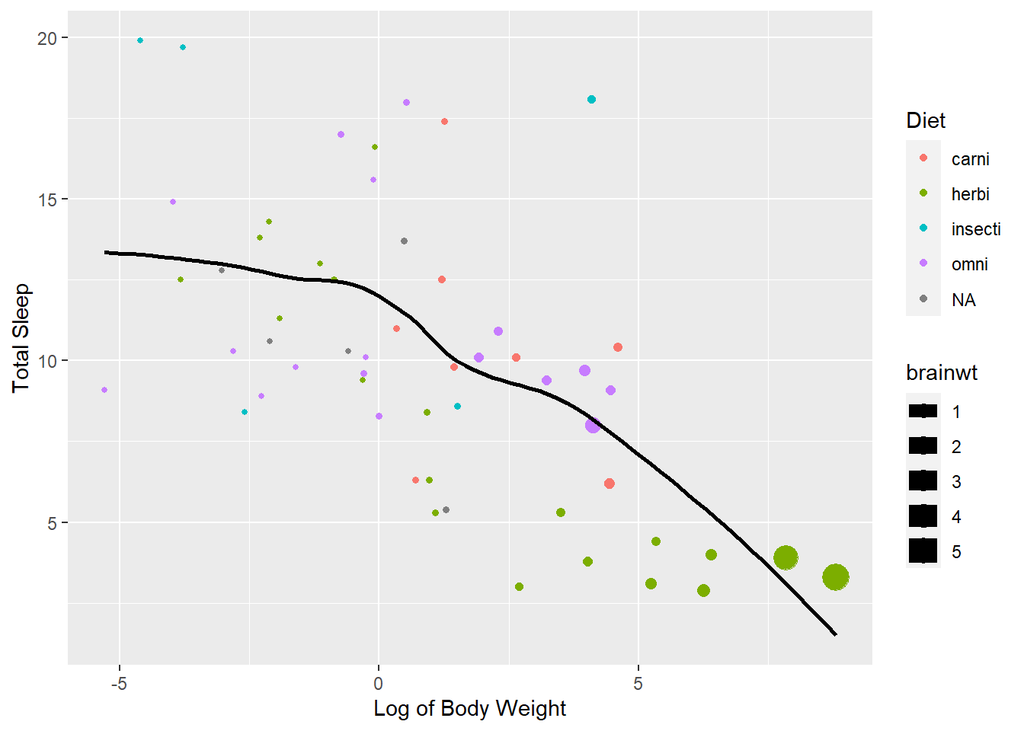

```r
sleep_plot <- ggplot(sleeping_data, aes(x = log(bodywt), y = sleep_total, color = vore, size = brainwt)) +
  geom_point() +
  geom_smooth(se = FALSE, color = "black") +
  labs(y = "Total Sleep", x = "Log of Body Weight", color = "Diet")

sleep_plot # Same as in 3b.1. since it also asked for a regression line
```

### 3b.3. Discuss patterns (2 points)

Do any patterns emerge, how strong is the relationship? If you think there is a relationship, using logic, why do you think this occurs? If you don’t think there is a relationship, why do you think there is no relationship?

There is a very weak pattern suggested based on the faceted plots. In general, it seems that, as body weight increases, the total hours of sleep decreases. However, I do not believe that this is a legitimate relationship, given that in some cases (ie. Insectivores), such relationship does not even exist. Furthermore, the body weight was logged for the above plots, further obscuring the relationship between weight and total sleep.

## 4. Troubleshooting (8 *points,* 2 per question)

The following three code chunks do not work. In simple language tell us

- What the code was supposed to do, (*mention if this invalid)*
- Why they do not work,
  - how the error message makes sense (*even if the error doesn’t say why the code didn’t work, it tries to give a hint),*
- Show how you debugged the code to figure out the mistake
- and then fix the error to make code chunk work

```r
# First write what you think this code is supposed to do
x <- 7
if(x > 10) {
  print("x > 10")
 else { # Need to add } in front of else to make continue the statement
  print("x <= 10")
 }
```

T. The code for the if statement will conclude at the end of the line with the closing of the curly brace. Since this code chunk begins the else statement on the next line, it does not recognize the else statement as an extension of the original if statement. Thus, in order to incorporate the else statement, you must add the } to the front of the else clause. The following code chunk fixes the issue.

Reference: https://stackoverflow.com/questions/15586566/if-statement-in-r-can-only-have-one-line

```r
x <- 7
if(x > 10) {
  print("x > 10")
 } else {
  print("x <= 10")
 }
```

```r
rnorm(n = 3, var = 1)
```

The rnorm code above is meant to generate three random numbers by a normal distribution with a variance of 1. The second argument of the rnorm function should be sd and not var. The rnorm function does not recognize the argument var.

Reference: https://www.rdocumentation.org/packages/compositions/versions/2.0-8/topics/rnorm

```r
rnorm(n = 3, sd = 1)
```

```r
gender <- factor(c("female", "female", "male", "female", "male"))

Mean(gender)
```

```r
gender <- factor(c("female", "female", "male", "female", "male"))
gender_num <- as.numeric(gender) %>% mean() # Make new numeric vector to represent the original chracter vector and take mean

gender_num
```

```
[1] 1.4
```

*There are also certain scenarios where the code gives no error but it just doesn’t do what you would expect it to do, the example below is in this category. You need to understand the intent of this code, explain why it doesn’t do the intended thing and fix it..*

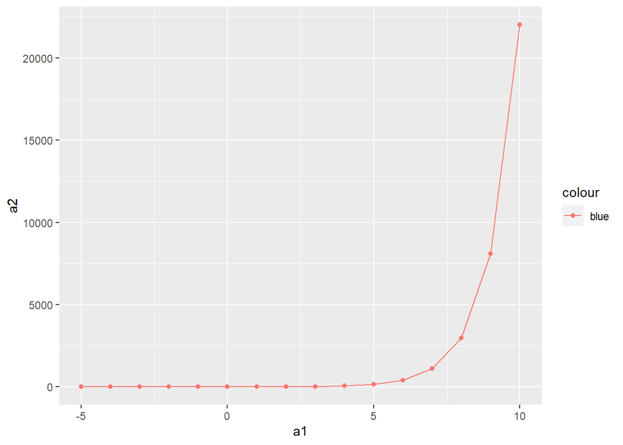

```r
a <- tibble(a1 = -5:10, a2 = exp(a1)) # Open tidyverse library first --> library(tidyverse)

ggplot(a, aes(a1, a2, colour = 'blue')) +
  geom_point() + geom_line()
```

In the above code, the purpose of the colour argument in the aes() is to make the plot blue. However, by placing the color argument within the aes() of the ggplot, it simply adds a legend entry “colour” and labels the plot as “blue”. To fix this issue, the colour argument should be specified in the geom_point() and/or geom_line() functions.

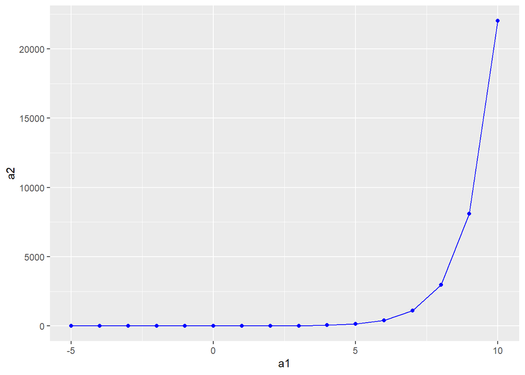

```r
a <- tibble(a1 = -5:10, a2 = exp(a1)) # Open tidyverse library first --> library(tidyverse)

ggplot(a, aes(a1, a2)) +
  geom_point(colour = 'blue') + geom_line(colour = 'blue')
```

## 5. Make a better ggplot (12 points)

This is a beginner plot that tries to explore how each mammal’s sleep duration depends on their phylogenetic order. Your goal is to improve this plot to make it easier to grasp + more informative!

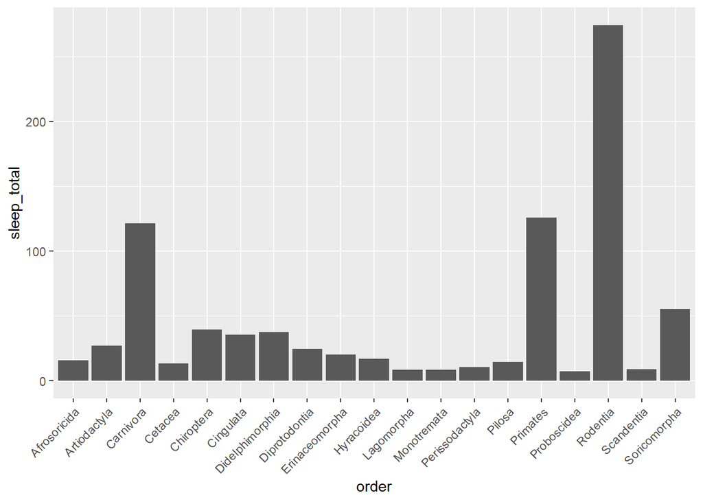

```r
# Sleeping labels on a sleeping plot, with a y axis that makes my head tilt
ggplot(sleeping_data, aes(order, sleep_total)) +
         geom_bar(stat = 'identity') +
  theme(axis.text.x = element_text(angle = 45, hjust = 1))
```

Find the target plot that you want to work towards as an attachment on canvas `sleep_barplot.png`

### 5a. Discuss visual choices (5 points)

Contrast the output of the initial barplot with the desired final plot and make 5 brief observations to answer - *In what aspects is latter better than the former?*

*Hints:* [barbarplots](https://thenode.biologists.com/barbarplots/photo/); [horizontal bars](https://www.storytellingwithdata.com/blog/2012/10/my-penchant-for-horizontal-bar-graphs); William Chases’ glamour of graphics [talk](https://www.youtube.com/watch?v=h5cTacaWE6I),

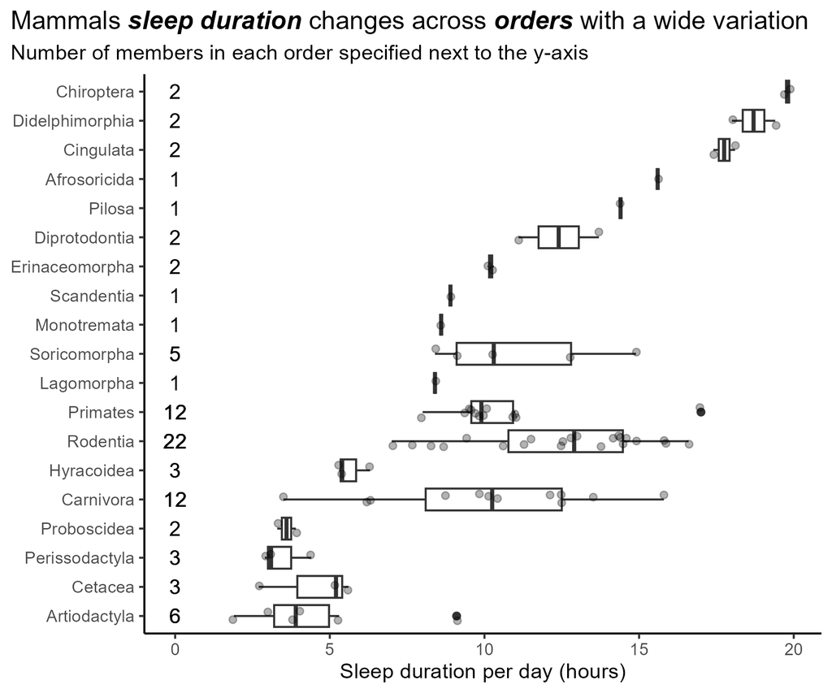

[figure not shown]

1. The final plot swaps the x and y axis variables, placing the order on the y-axis and the sleep_total on the x-axis
2. The final plot uses a box plot as opposed to a bar graph
3. The final plot also adds a label to the sleep_total axis as “Sleep duration per day (hours)” to provide clarity for what the sleep measurement represents
4. The final plot also provides a count for how many entries appear for each order
5. The final product does not use the total sleep across the order, but rather it uses the individual values which makes the data more digestible. For instance, for the *Rodentia* order, seeing the order having over 200 hours of total sleep is not a meaningful piece of information.

### 5b. Improve the plot (7 points)

Now, try to improve the plot to tend towards the desired plot step by step. You can either do it in a single chunk or use multiple chunks with each step being added serially.

*Don’t worry about getting it perfectly alright, just try to get each element in as much as you can and show what you tried for the ones that didn’t work.*

Hints :

1. replace bar with boxplot, flip the coordinates so that labels are not tilted anymore (1 point)
2. Overlay points on the boxplot with some transparency (1 point)
   1. Add some noise to the points using `position_jitter()`, (2 points)
3. Add proper axis labels (1 point)
4. Add text using `geom_text()` based on the number of counts (1 point)
5. modifying title position in `theme()` (1 point)

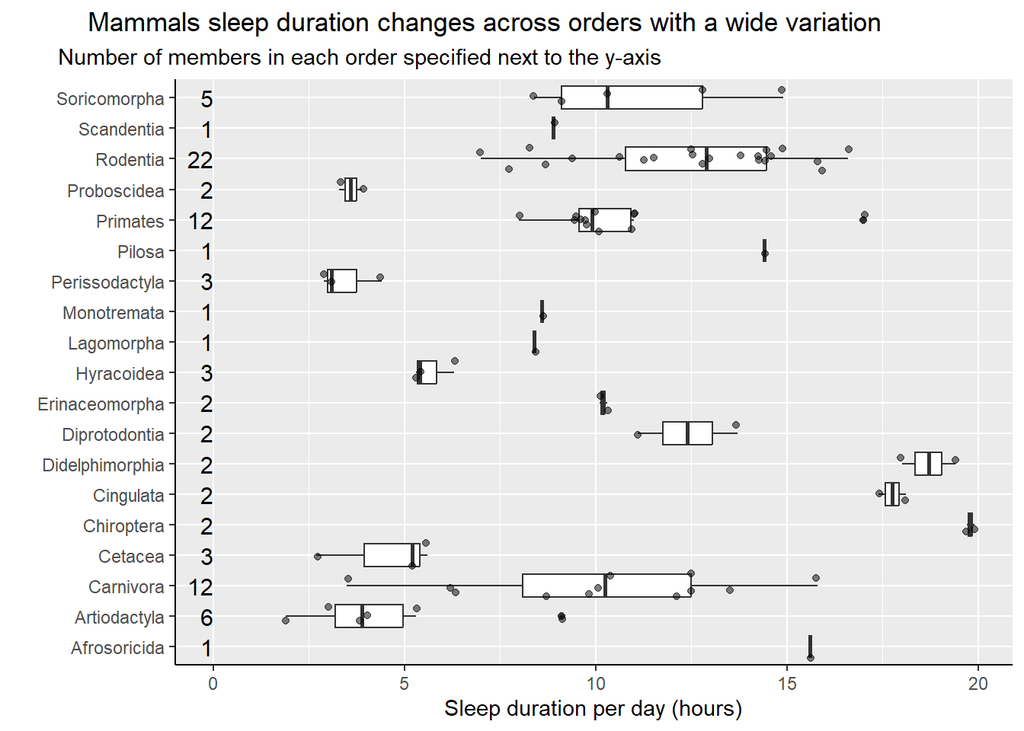

```r
# improved plot
sleep_order <- sleeping_data %>% group_by(order) %>% mutate(count = n()) # Create new dataset that counts the number of individuals in each order

sleep_order_plot <- ggplot(sleep_order, aes(x = sleep_total, y = order)) + # Swapped axis so labels are no longer tilted
  geom_boxplot()+ # Replacing the bar graph with box and whisker
  geom_point(position = "jitter", alpha = 0.5) + # Overlaying points on the boxplot with "small random variation" in location; also decreasing the opacity of the points.
  labs(x = "Sleep duration per day (hours)", y = "", title = "Mammals sleep duration changes across orders with a wide variation", subtitle = "Number of members in each order specified next to the y-axis") + # Labeling
  theme(plot.title = element_text(hjust = -2), plot.subtitle = element_text(hjust = -0.5), axis.line = element_line(colour = "black")) + # Moving title/subtitle to centralize them for better readibility
  geom_text(data = sleep_order %>% distinct(order, .keep_all = TRUE), # Adding count for the number of individuals in each order
            aes(y = order, x = 0, label = count),
            hjust = 1,
            size = 4,
            angle = 0)
  sleep_order_plot
```

```r
  # References: https://ggplot2.tidyverse.org/reference/geom_jitter.html
  # ...         https://ggplot2.tidyverse.org/reference/aes_colour_fill_alpha.html
```

### 5c.bonus. Rearrange data order (+1 point)

Re-arrange the data in a nice order to make the plot more pleasing. *You will have to use* `arrange()` and `fct_inorder()` functions

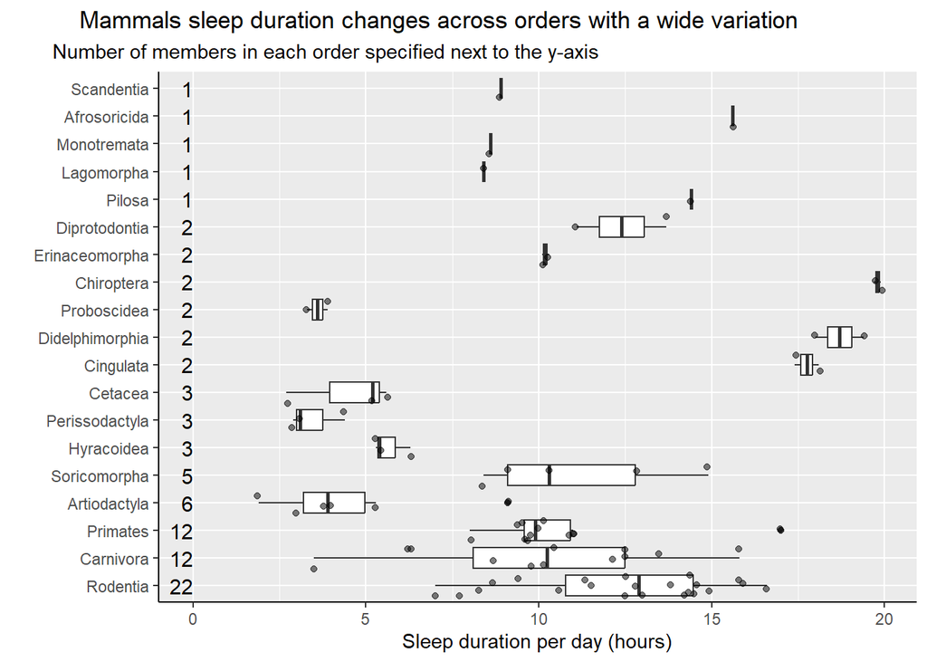

```r
# Recreating dataset so that the order is displayed in descending order of count
sleep_arranged <- arrange(sleep_order, desc(count))

# Mostly the same coding for original improved plot, but specify to graph box plots in order that they apear in dataset (arranged by
#... count)
ggplot(sleep_arranged, aes(x = sleep_total, y = fct_inorder(order))) + # Swapped axis so labels are no longer tilted
  geom_boxplot()+ # Replacing the bar graph with box and whisker
  geom_point(position = "jitter", alpha = 0.5) + # Overlaying points on the boxplot with "small random variation" in location; also decreasing the opacity of the points.
  labs(x = "Sleep duration per day (hours)", y = "", title = "Mammals sleep duration changes across orders with a wide variation", subtitle = "Number of members in each order specified next to the y-axis") + # Labeling
  theme(plot.title = element_text(hjust = -2), plot.subtitle = element_text(hjust = -0.5), axis.line = element_line(colour = "black")) + # Moving title/subtitle to centralize them for better readibility
  geom_text(data = sleep_order %>% distinct(order, .keep_all = TRUE), # Adding count for the number of individuals in each order
            aes(y = order, x = 0, label = count),
            hjust = 1,
            size = 4,
            angle = 0)
```

```r
# Reference: https://stackoverflow.com/questions/4260698/r-ordering-in-boxplot
```

### 5d.bonus. format title text (+1 point)

Make the words in the title text referring to the x and y axis to be distinguished (bold/italics/other colours). Can use a markdown formatter as in [ggtext](https://wilkelab.org/ggtext/articles/theme_elements.html)

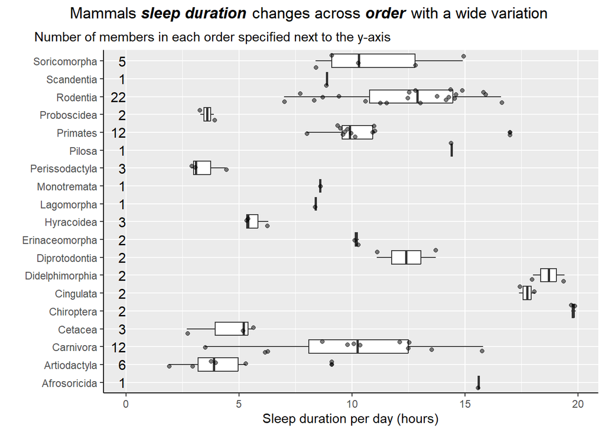

```r
new_title <- expression(paste("Mammals", bolditalic(" sleep duration"), " changes across", bolditalic(" order"), " with a wide variation")) # Write formatting for new title so I can simply plug it in as an argument for my labs()


ggplot(sleep_order, aes(x = sleep_total, y = order)) + # Swapped axis so labels are no longer tilted
  geom_boxplot()+ # Replacing the bar graph with box and whisker
  geom_point(position = "jitter", alpha = 0.5) + # Overlaying points on the boxplot with "small random variation" in location; also decreasing the opacity of the points.
  labs(x = "Sleep duration per day (hours)", y = "", title = new_title, subtitle = "Number of members in each order specified next to the y-axis") + # Labeling
  theme(plot.title = element_text(hjust = -2), plot.subtitle = element_text(hjust = -0.5), axis.line = element_line(colour = "black")) + # Moving title/subtitle to centralize them for better readibility
  geom_text(data = sleep_order %>% distinct(order, .keep_all = TRUE), # Adding count for the number of individuals in each order
            aes(y = order, x = 0, label = count),
            hjust = 1,
            size = 4,
            angle = 0)
```

```r
# Reference: https://stackoverflow.com/questions/67504377/how-to-use-bold-italic-and-underline-in-ggplot2
```

## 6. Vectorized function (6 points)

- Write a function that takes two or more numbers and adds them, called `plus`. (*1 point*)

  ```r
  # Naming a custom function "plus" that will take two inputs and add those two numeric values together.
  plus <- function(a,b,...){a+b+...}

  plus(3,4,5)
  ```

  ```
  [1] 12
  ```

- Modify this function now such that it can also take `characters` (instead of numbers), and combines them using the `cat()` function. (*2 points*)

  ```r
  #
  plus_mod <- function(...){ # Modifying function so that if all of the arguments are numerical values,
    x <- c(...)
    if (class(x)=="numeric"){
      print(sum(x)) # the function will print the sum of the arguments
    } else { # Otherwise, the function will combine the arguments into a character string
      return(capture.output(cat(x, sep = "")))
    }
  }

  plus_mod(1,2,3)
  ```

  ```
  [1] 6
  ```

  ```r
  plus_mod(1,2,"f")
  ```

  ```
  [1] "12f"
  ```

  ```r
  # References: https://www.rdocumentation.org/packages/base/versions/3.6.2/topics/cat
  # ...         https://www.rdocumentation.org/packages/utils/versions/3.6.2/topics/capture.output
  ```

- Now either modify this function or encompass this within another function (call it `vector_plus`) to work when the arguments provided are vectors (*of the same length*) rather than single objects. **This function should output a vector of the same size as each of the input arguments**. (*3 points*)

```r
vector_plus <- function(...) {
  a <- list(...)
  vec_out <- c()
  for (i in 1:length(a[[1]])) {
    v <- c()
    for (j in 1:length(a)) {
      v <- append(v, a[[j]][i])
    }
    vec_out <- append(vec_out, plus(v))
  }
  return(vec_out)
}

vector_plus(1:3, c("a", "b", "c")) # "1a" "2b" "3c"
vector_plus(1:3, 4:6) # "14" "25" "36"
vector_plus(c(1,4,5), c(4,5,8), c(5,9,3)) # 10 18 16
vector_plus(c(1,4,5), c(4,5,8), c("x", "y", "z")) # "14x" "45y" "58z"
```

[output not shown]

### 6.b.bonus. Make an informative error (+*2 points*)

Use the necessary function that stops the code and returns an informative [error message](https://stackoverflow.com/a/12723837/9049673) when the vectors are not of the same length (*since you can’t do one-to-one computation with them*).

```r
vector_plus <- function(...) {
  a <- list(...)
  if (!all(sapply(a, length) == length(a[[1]]))) {# sapply takes the length of all elements in a to compare the length of the input vectors.
  stop("Vector lengths do not match")
  }
  vec_out <- c()
  for (i in 1:length(a[[1]])) {
    v <- c()
    for (j in 1:length(a)) {
      v <- append(v, a[[j]][i])
    }
    vec_out <- append(vec_out, plus(v))
  }
  return(vec_out)
}

vector_plus(1:2, 1:3) # Displayed message: "Error in vector_plus(1:2, 1:3) : Vector lengths do not match"

# Reference: https://www.guru99.com/r-apply-sapply-tapply.html
```

Note: For all the prompts above, **call your function** and **show us the result for each clause** provided

## 7. Vectorize anything (3 points)

Use a `for` loop to print the **column name** and the **data type** of each column in the `sleeping_data` tibble from above (*3 points*)

```r
for (i in colnames(sleeping_data)) { # Iterate the for loop across the columns of sleeping_data
  data_type <- class(sleeping_data[[i]]) # Find the class type of each column
  print(paste(i, "-", data_type)) # data_type is a numeric, so use paste to convert to a character string; add hyphen
}                                 # ... to display data type next to the name of the column
```

```
[1] "name - character"
[1] "genus - character"
[1] "vore - character"
[1] "order - character"
[1] "conservation - character"
[1] "sleep_total - numeric"
[1] "sleep_rem - numeric"
[1] "sleep_cycle - numeric"
[1] "awake - numeric"
[1] "brainwt - numeric"
[1] "bodywt - numeric"
```

### 7a.bonus. Using vectorization (+3 points)

Do the same now using vectorization instead of a loop - using the `map()` function (or any other such function). (+*1 point*)

You would have noticed that the output of the `map()` command is a list. It prints each entry of the list one below the other and is not space efficient to concisely display the column name and type of all 11 variables without needing to scroll. Find a better way to display this by returning any other data type or convert the list into a named vector. *Make sure that both the column name and the type are visible!* (+*1.5 points*)

- *Document your sources including which package this function is from and how you learned to use it* *in short* (+*0.5 point*)

```r
sleep_col_data <- map(sleeping_data, class) # Returns list of the data type for each colum in sleeping_data
sleep_col_data
```

```
$name
[1] "character"

$genus
[1] "character"

$vore
[1] "character"

$order
[1] "character"

$conservation
[1] "character"

$sleep_total
[1] "numeric"

$sleep_rem
[1] "numeric"

$sleep_cycle
[1] "numeric"

$awake
[1] "numeric"

$brainwt
[1] "numeric"

$bodywt
[1] "numeric"
```

```r
sleep_col_data_vec <- map_vec(sleeping_data, class) # Returns classes as a character vector
sleep_col_data_vec
```

```
        name        genus         vore        order conservation  sleep_total
 "character"  "character"  "character"  "character"  "character"    "numeric"
   sleep_rem  sleep_cycle        awake      brainwt       bodywt
   "numeric"    "numeric"    "numeric"    "numeric"    "numeric"
```

```r
# Reference: https://purrr.tidyverse.org/reference/map.html
# These functions are part of the purrr package in Tidyverse
```

## 8. Plot multiple columns (*5 points*)

- Use the dataset `df` below, plot y1, y2 and y3 in 3 different colours (*2 points*)

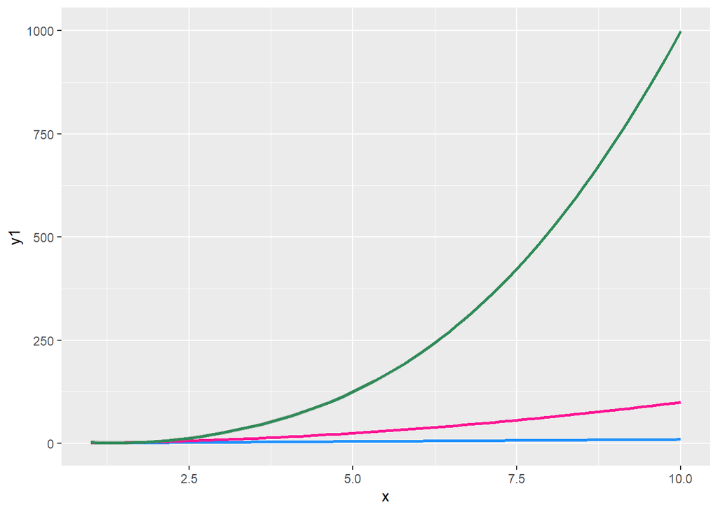

```r
# plotting here
df <- tibble(x = 1:10, y1 = x, y2 = x^2, y3 = x^3)
ggplot(df, aes(x = x))+
  geom_smooth(aes(y = y1), colour = "dodgerblue") +
  geom_smooth(aes(y = y2), colour = "deeppink") +
  geom_smooth(aes(y = y3), colour = "seagreen")
```

- Use `pivot_longer()` to reshape the data and make a similar `ggplot` with different colours (2+*1 points*) (learn how to use the `pivot_wider()` function from documentation and cite your sources)

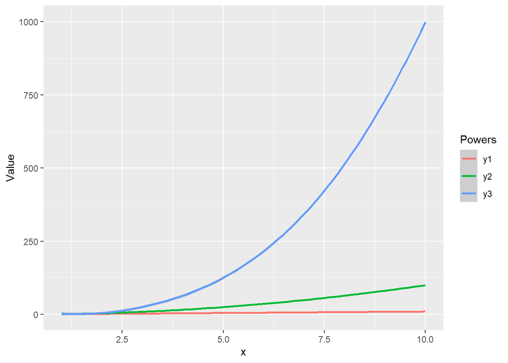

```r
df_pivot <- pivot_longer(df, cols = c(y1, y2, y3), names_to = "Powers", values_to = "Value")

ggplot(df_pivot, aes(x = x, y = Value, color = Powers)) +
  geom_smooth()
```

```r
# Reference: https://tidyr.tidyverse.org/reference/pivot_longer.html
```

### 8.b.bonus. Why is `pivot_longer()` better here?

(bonus) Discuss how this `pivot_longer` approach would be helpful compared to the previous approach (*1 point*)

For the pivot_longer, we do not have to code each plot individually using geom_smooth. Rather, pivot_longer condenses the columns by moving all y1, y2, and y3 values into the same column titled “Powers”. Then, the pivot_longer function differentiates the entries under the “Powers” column and plots these values as three different plots on the same graph.

Reference: https://tidyr.tidyverse.org/reference/pivot_longer.html

# Attributions

For the questions, I would like to acknowledge these sources of inspiration

- Annie for many questions
- Sam for quality control and Q4 idea
- R errors from [statsandr.com](https://statsandr.com/blog/top-10-errors-in-r/#unmatched-parentheses-curly-braces-square-brackets-or-quotes)
- Nice list of [css colours](https://duckduckgo.com/?t=ffab&q=css+colours&ia=answer&iax=answer) to format a `.class` of text in a particular colour to distinguish it from questions (*if you are curious, you can change the colour of all your answers from firebrick to something else by doing* `find-and-replace` in the `Source` mode! **+1 bonus point** for this)

For the solutions

I would like to acknowledge various sources such as StackOverflow forums, RDocumentation, ggplot Documentation, and all of the linked resources provided within the assignment, Furthermore, I would like to acknowledge my groupmates Seungheon Lee and Gary Shi for our collaboration throughout the assignment.

Space for TA/grader comments here!

(copy this in the middle of the code for more elaborate comments)